# SPOTCHECK NO. 3

Reister L. Ruedas

#### Instructions

Submit this Rmd file on blackboard. Don’t submit additional files.

Code should be clearly commented. Plots should be presentable and properly labeled/titled. Mitigate overplotting whenever possible.

You may hard code whatever written answers are required.

#### Preliminaries

Here are some libraries that you may need.

```r
library(ggplot2)
library(plyr)
library(reshape2)
library(knitr)
library(binom)
```

We will use the data files `county_data.csv` and `county_ggplot.rda`, which were part of the lecture materials. We’ll assume they are in the same directory as this .Rmd file.

```r
county.data = read.csv(file = 'county_data.csv', header=TRUE)
load('county_ggplot.rda')
```

#### Questions

**Problem 1:**

Make a scatterplot of the per capita violent crime rates for each county as function of the population. Remember to mitigate overplotting. Does this plot resemble those for deaths, births, or infant deaths that we saw in the notes? If not, what is the biggest difference?

Note: you may want to use a log transform on the x-axis to see the data more clearly.

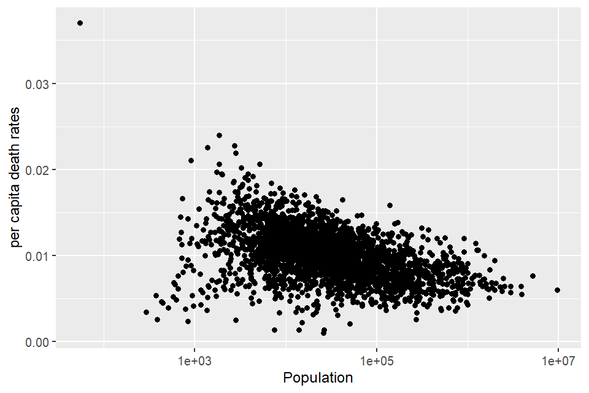

```r
# fill in with comments

ggplot(data=county.data,mapping = aes(x=population, y=(deaths/population))) + geom_point() + scale_x_log10() + labs(x = 'Population', y = 'per capita death rates')
```

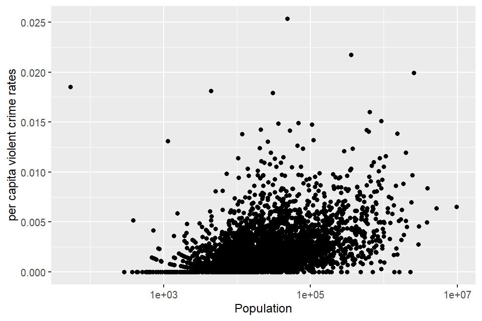

```r
#
ggplot(data=county.data,mapping = aes(x=population, y=(violent.crimes/population))) + geom_point() + scale_x_log10() + labs(x = 'Population', y = 'per capita violent crime rates')
```

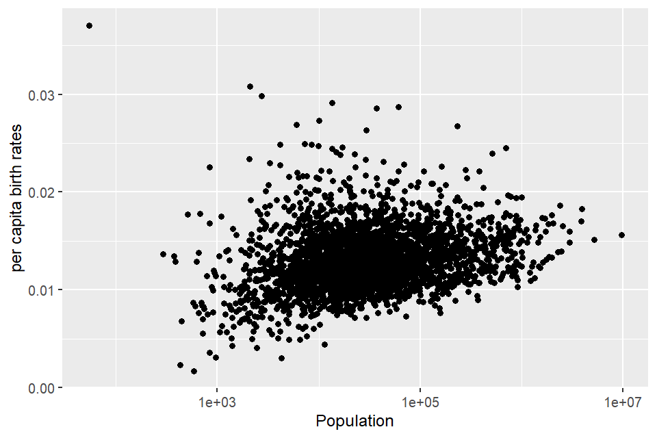

```r
#
ggplot(data=county.data,mapping = aes(x=population, y=(births/population))) + geom_point() + scale_x_log10() + labs(x = 'Population', y = 'per capita birth rates')
```

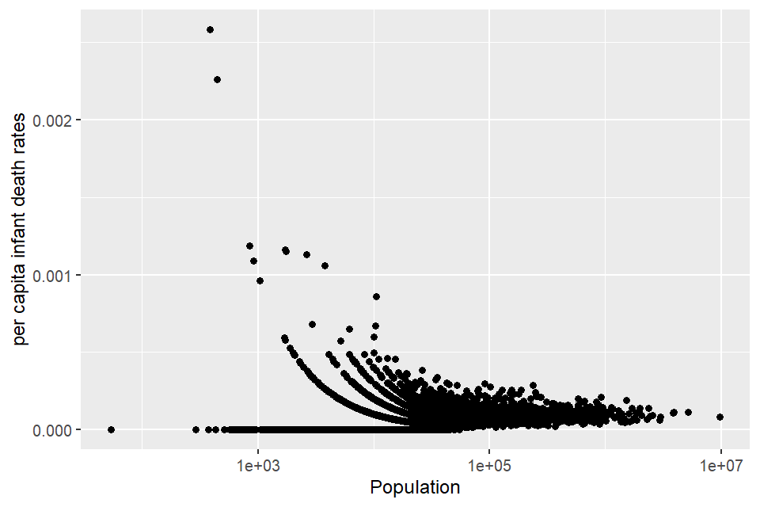

```r
#
ggplot(data=county.data,mapping = aes(x=population, y=(infant.deaths/population))) + geom_point() + scale_x_log10() + labs(x = 'Population', y = 'per capita infant death rates')
```

*ANSWER:* Looking at the chart about per capita death rates and the per capita infant death rates show a trend of relationship between the two in which one variable increases as the other decrease, while the chart about per capita birth rates shows a slightly increase in relation. Looking at the chart per capita violent crimes, it shows that at y axis there are 0 values, which means some counties has no violent crimes.

**Problem 2:**

Create a function called `find.std.residual()`, which lets you specify a column in the `county.data` data frame, and then uses the p-value approach to identify counties where people may potentially be at higher risk.

Specifically, your function should take the following inputs

- the `county.data` data set
- `variable`: the name of the column that you want to inspect
- `null.prob`: this variable determines the null hypothesis that you will compare all counties to. Specifically, the null is that all counties are `binomial(population, null.prob)` random variables.

Your function should return a data frame with all of the columns in `county.data`, plus the following additional columns

- `expected.null`: the expected number of outcomes under the null hypothesis for each county
- `variance.null`: the variance under the null hypothesis for each county
- `residual`: the difference between the observed count and that predicted under the null
- `std.residual`: the standardized residual

The rows of the data frame should be sorted in decreasing order by `std.residual`

Be sure to comment your function thoroughly so that it is easy to understand later.

```r
# fill in with comments
find.std.residual <- function(county.data, variable, null.prob){

  # The sample standard deviation is the square root of the calculated variance of a sample data set.
    new.data = mutate(county.data,  expected.null = population * null.prob, variance.null = population * null.prob * (1 - null.prob), residual = variable - expected.null, std.dev.null = sqrt(variance.null), std.residual = residual/std.dev.null)

    # arrange the data by std.residual from high to low to show top counties
    new.data <- arrange(new.data, desc(std.residual))

    #return the data frame
    new.data
}
```

**Problem 3:**

Use your function from problem 2 to create a table showing the top fifteen counties for `violent.crimes`, under a null hypothesis that each county has a crime per capita rate of 1%.

```r
# fill in with comments
head(find.std.residual(county.data, county.data$violent.crimes, 0.01), 15)
```

```
##                    name STCOU population violent.crimes births deaths
## 1             Kings, NY 36047    2539206          50556  41983  16410
## 2    St. Louis city, MO 29510     355663           7734   5348   3318
## 3            Shelby, TN 47157     919964          13894  15247   7626
## 4    Baltimore city, MD 24510     640150          10257   9712   7030
## 5      Philadelphia, PA 42101    1530031          21184  23615  15247
## 6          Franklin, KY 21073      48540           1231    658    415
## 7  District of Columbia 11001     586409           8325   8864   5188
## 8          Davidson, TN 47037     621384           8738   9992   4974
## 9             Wayne, MI 26163    1981238          23642  26442  18621
## 10           Orange, FL 12095    1066117          12379  16870   6536
## 11           Sumter, SC 45085     104223           1537   1688    973
## 12          Pulaski, AR  5119     374992           4630   6016   3306
## 13           Dillon, SC 45033      30735            551    526    335
## 14           Marion, IN 18097     878190          10025  15441   7043
```

[output cut: 17 more lines]

**Problem 4:**

Create a function `map.std.residual()` which takes the output of your function `find.std.residual()`, and creates a choropleth plot.

The inputs to the function should be

- `county.gg`: the data frame needed to draw the map
- `county.data`: the output from `find.std.residual()`

The output should be a map that can be printed, to which you can customize later by adding calls like `scale_fill_gradient2()` and `labs()`

Use this function to create a choropleth plot of the results from problem 3.

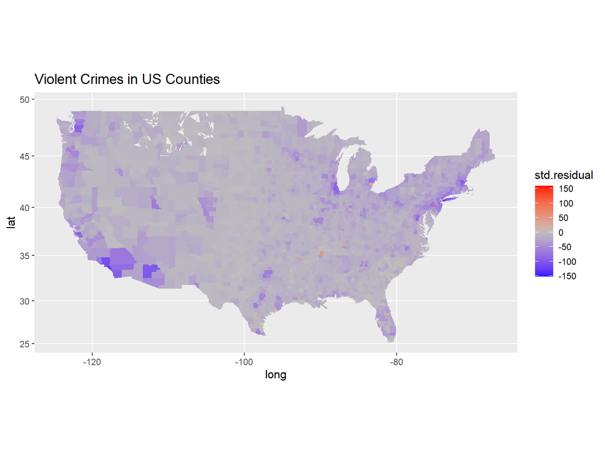

```r
# fill in with comments
map.std.residual <- function(county.gg, county.data){
  #use the function from problem number 3
  new.data <- find.std.residual(county.data, county.data$violent.crimes, 0.01)
  map <- merge(county.gg, new.data, by.x = 'fips', by.y='STCOU')
  # make the map
  ggplot(data = map, mapping=aes(x = long, y = lat, group = group, fill = std.residual)) +
  geom_polygon() +
  scale_fill_gradient2(low = 'blue', mid = 'grey', high = 'red', midpoint = 0) +
  coord_map() +
  labs(title = 'Violent Crimes in US Counties')
}

map.std.residual(county.gg, county.data)
```

**Problem 5:**

Using the functions you wrote, make a new choropleth plot and table, this time using the US violent crime per capita rate as your null hypothesis.

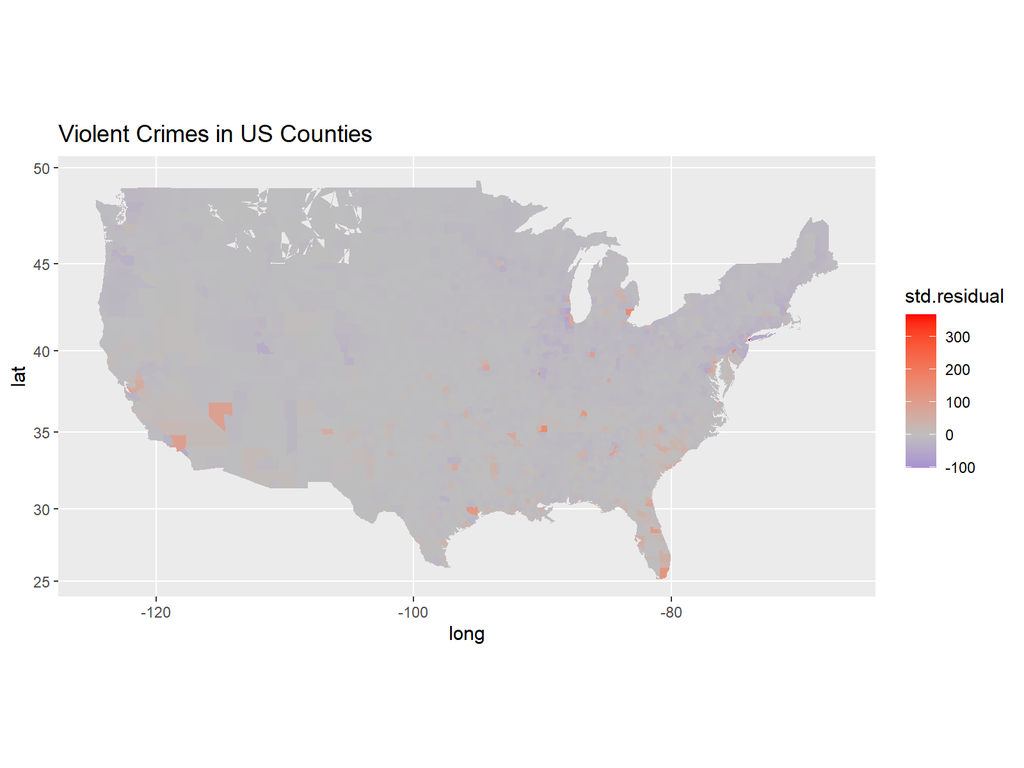

```r
# fill in with comments
# Compute for the overall US crime rate with the all of population
crime.rate = sum(county.data$violent.crimes)/sum(county.data$population)

map.std.residual <- function(county.gg, county.data){
  # Use computed US violent capita rate as null hypothesis
  new.data <- find.std.residual(county.data, county.data$violent.crimes, crime.rate)
  map <- merge(county.gg, new.data, by.x = 'fips', by.y='STCOU')
  # make the map
  ggplot(data = map, mapping=aes(x = long, y = lat, group = group, fill = std.residual)) +
  geom_polygon() +
  scale_fill_gradient2(low = 'blue', mid = 'grey', high = 'red', midpoint = 0) +
  coord_map() +
  labs(title = 'Violent Crimes in US Counties')
}

map.std.residual(county.gg, county.data)
```

```r
head(find.std.residual(county.data, county.data$violent.crimes, crime.rate), 15)
```

```
##                    name STCOU population violent.crimes births deaths
## 1             Kings, NY 36047    2539206          50556  41983  16410
## 2      Philadelphia, PA 42101    1530031          21184  23615  15247
## 3             Wayne, MI 26163    1981238          23642  26442  18621
## 4    St. Louis city, MO 29510     355663           7734   5348   3318
## 5            Shelby, TN 47157     919964          13894  15247   7626
## 6    Baltimore city, MD 24510     640150          10257   9712   7030
## 7        Miami-Dade, FL 12086    2453567          23740  34300  17982
## 8            Harris, TX 48201    3909239          32700  71409  21603
## 9          Davidson, TN 47037     621384           8738   9992   4974
## 10 District of Columbia 11001     586409           8325   8864   5188
## 11           Orange, FL 12095    1066117          12379  16870   6536
## 12           Marion, IN 18097     878190          10025  15441   7043
## 13      Los Angeles, CA  6037    9734701          63385 151908  58383
## 14           Fulton, GA 13121     990790          10452  14839   5851
```

[output cut: 33 more lines]

Comment on why the map and table from problem 5 are different from those of problems 4 and 3.

*ANSWER:* In the problem 5 most of areas are in grey and light blue, which implies they are close than the normal crime percentage, and not many of the provinces have a terrible circumstance, potentially a portion of the bad districts. In any case, if an area is dangerous, its crime percentage can be high, which would prompt a high std.residual. Contrasted with the problem 4 map, the problem 5 map has more terrible provinces, and the higher bad levels.